# Python tutorial

### Custom colormaps and the `midpoint` argument

You can pass any Matplotlib colormap (or create a custom one with `LinearSegmentedColormap`) to the `cmap` argument. Since this simulated data spans negative and positive values, a diverging blue-white-red colormap is a natural choice.

The `midpoint` argument specifies the center value of the color scale. Setting this to 0 maps the center color to 0, with symmetric bounds determined automatically from the data range (unless you also set `vmin` and `vmax` explicitly). Without explicitly setting vmin/vmax, the color range will be defined symmetrically around `midpoint` to capture the full range of the data.

```python
from subcortex_visualization.plotting import plot_subcortical_data
import matplotlib.colors as mcolors

# Create a blue-white-red colormap
white_blue_red_cmap = mcolors.LinearSegmentedColormap.from_list("BlueWhiteRed",
                                                                 ["blue", "white", "red"])

plot_subcortical_data(subcortex_data=example_continuous_data,
                      atlas='aseg_subcortex',
                      hemisphere='both',
                      fill_title="Normal distribution sample, aseg subcortex atlas",
                      cmap=white_blue_red_cmap, midpoint=0)
```

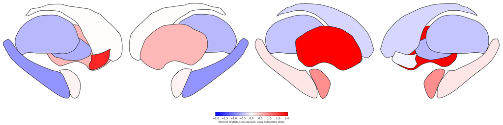

### Plotting categorical data

We've prepared a tabular dataset summarizing the broad category to which each region in the Melbourne Subcortex Atlas (7T) belongs; for example, 'thalamus' or 'hippocampus'. Let's look at the structure of this dataset:

```python
subcortex_region_category_lookup = (pd.read_csv("Melbourne_7T_categories.csv"))
subcortex_region_category_lookup.query("subcortex_parcel_res == 'S4'").head(10)
```

|  | region | category | subcortex_parcel_res |
| --- | --- | --- | --- |
| 52 | caudate_VA | caudate | S4 |
| 53 | caudate_DAi | caudate | S4 |
| 54 | caudate_DAs | caudate | S4 |
| 55 | caudate_post | caudate | S4 |
| 56 | hippocampus_head_med_1 | hippocampus | S4 |
| 57 | hippocampus_head_med_2 | hippocampus | S4 |
| 58 | hippocampus_head_lat_1 | hippocampus | S4 |
| 59 | hippocampus_head_lat_2 | hippocampus | S4 |
| 60 | hippocampus_body_med | hippocampus | S4 |
| 61 | hippocampus_body_lat | hippocampus | S4 |

Now let's plot the S4 resolution of the Melbourne Subcortex Atlas (7T), coloring each region by the corresponding category.

```python
category_df = (subcortex_region_category_lookup
               .query("subcortex_parcel_res == 'S4'")
               .assign(Hemisphere = 'L')
)

plot_subcortical_data(subcortex_data=category_df, atlas="Melbourne_S4_7T",
                      hemisphere='L',
                      value_column='category', cmap='YlGnBu',
                      fill_title="Melbourne S4 (7T) categories")
```

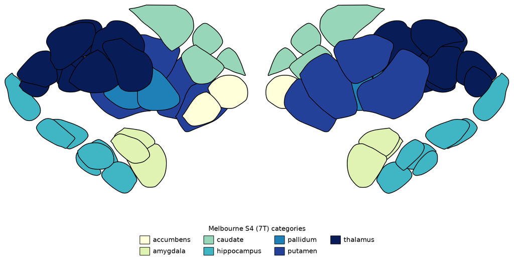

## 5. Extracting regional statistics from volumetric data

In many cases, you may have a three-dimensional volumetric image (from any imaging modality) and want to reduce it down to region-level summary statistics before plotting. The `parcel_segstats` function handles this: it takes a NIfTI image and an atlas name and computes a user-specified summary statistic for all voxels in each region.

For the `parc_stat` argument, you can pass any function that takes an array of values and returns a single scalar, such as `np.mean`, `np.std`, `np.median`, or `np.max`. You can also pass a list of functions to compute multiple statistics simultaneously, in which case the output DataFrame will have one row per region per statistic.

The output DataFrame is pre-formatted for direct use with `plot_subcortical_data` (no reformatting needed).

### Atlas space compatibility

The atlases are provided in two MNI spaces: `MNI152NLin6Asym` (default) and `MNI152NLin2009cAsym`. Your input volume must be in one of these two spaces to use our package to compute region-aggregated statistics in one or more of the included atlases. If the affine or spatial dimensions don't match, `parcel_segstats` will raise an error by default. You can specify an `interpolation` method (`'nearest'`, `'linear'`, or `'cubic'`) to resample the atlas to your input volume, though we encourage you to take care with atlas alignment and, wherever possible, normalize your data to the correct MNI space rather than relying on interpolation.

Here we compute the median CB1 receptor density per region in the aseg subcortex atlas from a group-averaged PET map:

```python
import numpy as np
import matplotlib
from subcortex_visualization import segmentation, plotting

# Define file paths
CB1_density_URL = "https://github.com/netneurolab/hansen_receptorvar/blob/main/data/PET_volumes/CB1_fmpepVt2_hc20_nummenmaa_mean.nii.gz?raw=true"

# Download the CB1 density map to a local file path
import requests
response = requests.get(CB1_density_URL)
with open("CB1_density_mean.nii.gz", "wb") as f:
    f.write(response.content)
functional_map_path = "CB1_density_mean.nii.gz"
atlas_name = "aseg_subcortex"
func_name = "CB1_density"

# The PET maps are shared in MNI152NLin6Asym space, so we specify
# this space for the atlas to ensure proper alignment
atlas_space = 'MNI152NLin6Asym'

# Apply the aseg subcortex atlas to extract the median value per region,
# specifying interpolation='nearest' to preserve discrete labels in the atlas
this_func_atlas_data = segmentation.parcel_segstats(
    input_vol=functional_map_path,
    atlas_space=atlas_space,
    atlas=atlas_name,
    func_name=func_name,
    parc_stat=np.median,
    interpolation='nearest'
)

# Custom color map
custom_cmap = mcolors.LinearSegmentedColormap.from_list("this_atlas_cmap", ["white", "#00405c"])

plotting.plot_subcortical_data(
    subcortex_data=this_func_atlas_data,
    atlas=atlas_name, value_column='value',
    fill_title='Median CB1 density - aseg subcortex atlas',
    hemisphere='both', show_legend=True, show_figure=True, cmap=custom_cmap
)

# Clean up the downloaded file
os.remove("CB1_density_mean.nii.gz")
```

```
Resampling atlas 'aseg_subcortex' to match input data affine and dimensions using nearest interpolation...
```

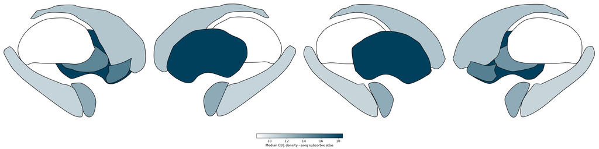

### Applying multiple atlases simultaneously

`parcel_segstats` accepts a list of atlas names, running the parcellation for each and concatenating results into one DataFrame with an `Atlas` column. This makes it straightforward to compare how regional patterns differ across parcellation schemes.

As long as your empirical volume is in one of the two supported MNI spaces, you can flexibly mix any combination of atlases and summary statistics in a single function call.

Here we compute the mean GABA<sub>A</sub>-$\alpha$ 1 receptor subunit density across all sixteen atlases included in the package:

```python
import numpy as np
import pandas as pd
import matplotlib.pyplot as plt
from subcortex_visualization import segmentation, plotting

# Define subcortical atlases
all_atlases = ['aseg_subcortex', 'Melbourne_S1', 'Melbourne_S2',
               'Melbourne_S3', 'Melbourne_S4',
               'Melbourne_S1_7T', 'Melbourne_S2_7T', 'Melbourne_S3_7T', 'Melbourne_S4_7T',
               'AICHA_subcortex',
               'Brainnetome_subcortex', 'CIT168_subcortex', 'Thalamus_HCP',
               'Thalamus_THOMAS', 'Brainstem_Navigator', 'SUIT_cerebellar_lobule']

parc_stat = np.nanmean
atlas_space = 'MNI152NLin6Asym'

# Define paths
GABAa1_density_URL = "https://github.com/netneurolab/hansen_receptorvar/blob/main/data/PET_volumes/GABAa1_ro154513_hc23_chang_mean.nii.gz?raw=true"

# Download the GABA_A_a1 density map to a local file path
response = requests.get(GABAa1_density_URL)
func_map_path = "GABAa1_density_mean.nii.gz"
with open(func_map_path, "wb") as f:
    f.write(response.content)
func_name = "GABA_A_a1_density"

# Extract mean values for all atlases from the GABA_A_a1 density map
# Use nearest neighbor interpolation to preserve discrete labels in the atlas
func_map_subcortical_parc_df = segmentation.parcel_segstats(
    input_vol=func_map_path,
    atlas=all_atlases,
    atlas_space=atlas_space,
    parc_stat=parc_stat,
    ignore_background=True,
    func_name=func_name,
    interpolation='nearest'
)

this_vmin = func_map_subcortical_parc_df['value'].min()
this_vmax = func_map_subcortical_parc_df['value'].max()

# Plot each atlas with a consistent color scale
for atlas in all_atlases:
    this_atlas_data = func_map_subcortical_parc_df.query("Atlas == @atlas")
    this_fill_title = f"{func_name} - {atlas}"

    this_atlas_plot = plotting.plot_subcortical_data(
        subcortex_data=this_atlas_data,
        atlas=atlas,
        value_column='value',
        fill_title=this_fill_title,
        hemisphere='both',
        vmin=this_vmin,
        vmax=this_vmax,
        cmap='plasma',
        show_legend=True,
        show_figure=False
    )
```

[output not shown]

[output cut: 26 more lines]

[output not shown]

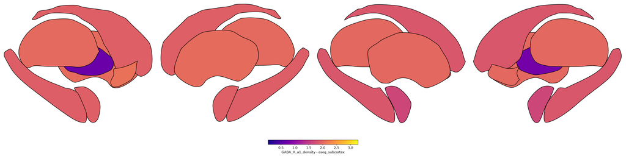

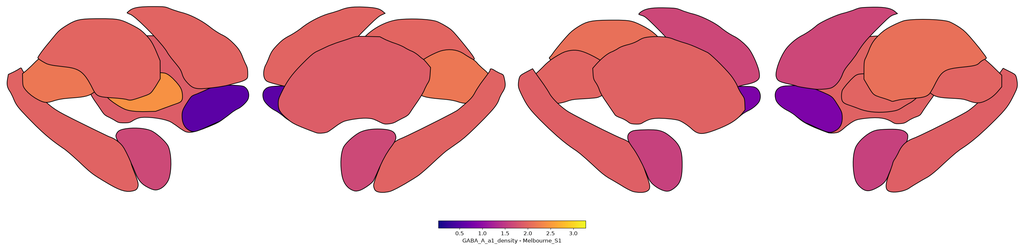

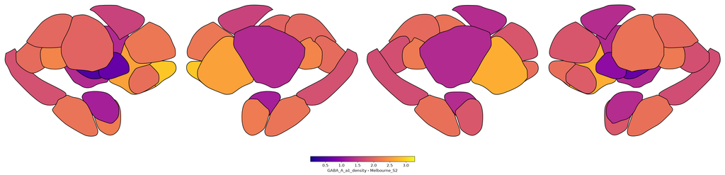

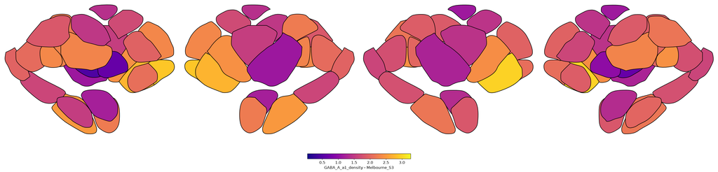

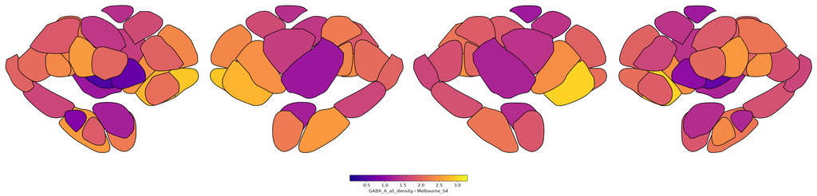

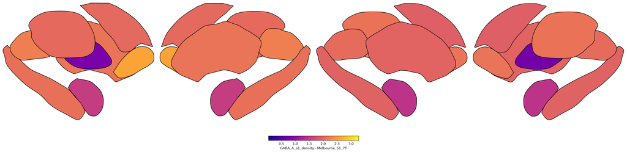

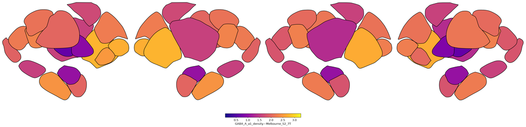

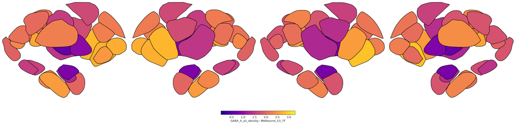

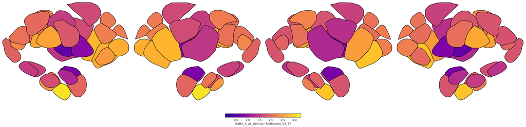

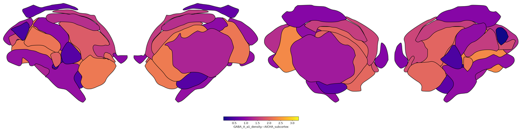

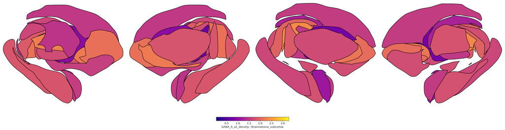

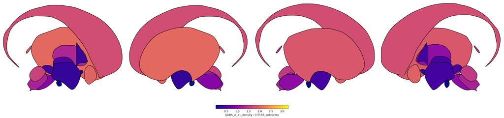

[4 more figures not shown]

## 6. Combining cortical and subcortical visualizations

Since `plot_subcortical_data` returns a Matplotlib Figure object (when `show_figure=False`), Python users can save it alongside any other figure (e.g., a cortical surface plot from `ggseg` in R or a `nilearn` glass brain) and combine them in their preferred image editor, like Inkscape or Adobe Illustrator.

To compute cortical parcellation statistics in Python, we can use the `neuromaps` package to project a volumetric PET map to a surface and then parcellate it with any parcellation scheme. The example below uses the Schaefer 1000-parcel atlas in `fsaverage` space.

> **Note:** This section requires additional dependencies: `netneurotools`, `neuromaps`, and Connectome Workbench. See the [neuromaps documentation](https://netneurotools.readthedocs.io/) for installation instructions.

```python
import numpy as np
import pandas as pd
from subcortex_visualization import segmentation, plotting

# For cortical data visualization
from netneurotools import datasets as nntdata
import neuromaps
from neuromaps import transforms, images
from neuromaps.parcellate import Parcellater
from neuromaps.images import dlabel_to_gifti

# Add connectome workbench to path; adjust for your system
os.environ['PATH'] = os.environ['PATH'] + ':/Applications/workbench/bin_macosx64'

# Define file paths
func_map_path = "GABAa1_density_mean.nii.gz"
func_name = "GABA_A_a1_density"

# Transform functional map to fsaverage surface
func_map_in_surf = transforms.mni152_to_fsaverage(func_map_path, method='nearest')

# Download and read in the Schaefer 1000-parcel lookup table
s1000_url = (
    "https://raw.githubusercontent.com/ThomasYeoLab/CBIG/master/stable_projects/"
    "brain_parcellation/Schaefer2018_LocalGlobal/Parcellations/MNI/freeview_lut/"
    "Schaefer2018_1000Parcels_17Networks_order.txt"
)
schaefer1000_lookup = pd.read_csv(s1000_url, header=None, sep='\t')[[0, 1]]
schaefer1000_lookup.columns = ['index', 'label']
schaefer1000_labels = schaefer1000_lookup.label.tolist()

# Download Schaefer parcellations in fsaverage space
schaefer_fsaverage = nntdata.fetch_schaefer2018(version='fsaverage')
schaefer_fsaverage_1000 = schaefer_fsaverage['1000Parcels17Networks']

# Convert 1000-parcellation into gifti space
schaefer_res_gifti = neuromaps.images.annot_to_gifti(schaefer_fsaverage['1000Parcels17Networks'])
schaefer_res_gifti = neuromaps.images.relabel_gifti(schaefer_res_gifti)

# Fit a Parcellator object
parc = Parcellater(schaefer_res_gifti, 'fsaverage', resampling_target='parcellation')
func_map_in_surf_parc = parc.fit_transform(func_map_in_surf, 'fsaverage',
                                            ignore_background_data=True)

# Create a dataframe with the parcellated cortical data
func_map_cortical_parc_df = (pd.DataFrame({
    'region': schaefer1000_labels,
    'Atlas': 'Schaefer1000_17Networks',
    'value': func_map_in_surf_parc
}).assign(Hemisphere=lambda x: np.where(x['region'].str.contains('LH'), 'L', 'R')))
```

```
Dataset atl-schaefer2018 already exists. Skipping download.
```

```python
import numpy as np
import pandas as pd
import matplotlib.pyplot as plt
from subcortex_visualization import segmentation, plotting

# Define subcortical atlases
all_atlases = ['aseg_subcortex', 'Melbourne_S1', 'Melbourne_S2',
               'Melbourne_S3', 'Melbourne_S4',
               'Melbourne_S1_7T', 'Melbourne_S2_7T', 'Melbourne_S3_7T', 'Melbourne_S4_7T',
               'AICHA_subcortex',
               'Brainnetome_subcortex', 'CIT168_subcortex', 'Thalamus_HCP',
               'Thalamus_THOMAS', 'Brainstem_Navigator', 'SUIT_cerebellar_lobule']

atlas_space = 'MNI152NLin6Asym'
func_map_path = "GABAa1_density_mean.nii.gz"
func_name = "GABA_A_a1_density"

# Extract mean values for all atlases from the GABA_A_a1 density map
# Use nearest neighbor interpolation to preserve discrete labels in the atlas
func_map_subcortical_parc_df = segmentation.parcel_segstats(
    input_vol=func_map_path,
    atlas=all_atlases,
    atlas_space=atlas_space,
    parc_stat=np.nanmean,
    ignore_background=True,
    func_name=func_name,
    interpolation='nearest'
)

# Combine with cortical data from previous code cell
func_map_all_parc_df = pd.concat([func_map_cortical_parc_df, func_map_subcortical_parc_df], axis=0)

# Get min and max values across all atlases for consistent color scaling
this_vmin = func_map_all_parc_df['value'].min()
this_vmax = func_map_all_parc_df['value'].max()

# Plot each atlas with consistent color scale
for atlas in all_atlases:
    this_atlas_data = func_map_all_parc_df.query("Atlas == @atlas")
    this_fill_title = f"{func_name} - {atlas}"

    this_atlas_plot = plotting.plot_subcortical_data(
        subcortex_data=this_atlas_data,
        atlas=atlas,
        value_column='value',
        fill_title=this_fill_title,
        hemisphere='both',
        vmin=this_vmin,
        vmax=this_vmax,
        cmap='plasma',
        show_legend=False,
        show_figure=False
    )

# Clean up the downloaded file
os.remove("GABAa1_density_mean.nii.gz")
```

[output not shown]

[output cut: 26 more lines]

[output not shown]

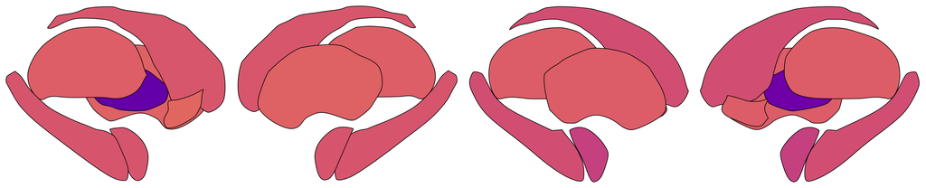